# Shiny exercises: beginner level

First things first: package installation…

```r
# install.packages("shiny")             # Shiny
# install.packages("shinydashboard")    # Shiny dashboards
# install.packages("DT")                # Package for datatables (just in case)
```

… and activation + load the data. MAKE SURE THE *songs.RData* and *movies.RData* files are in the right place!

```r
library(tidyverse)        # Just to be sure it's the first thing that is done...
library(shiny)
library(shinydashboard)
library(DT)

load("songs.RData")
load("movies.RData")
```

# Songs dataset: exercises

The empty dashboard is given below:

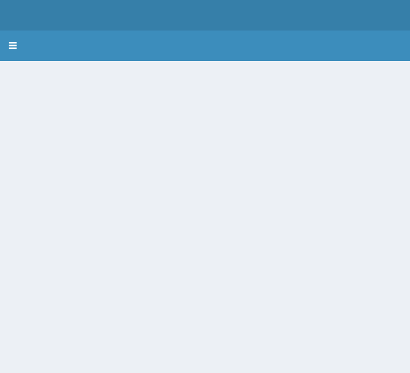

```r
ui <- dashboardPage(           # FULL PAGE
    dashboardHeader(),         # Header zone
    dashboardSidebar(),        # Sidebar zone
    dashboardBody()            # Body zone
)

server <- function(input, output){  # Server: computations!

}

# Run the app ----
shinyApp(ui = ui, server = server)  # Aggregates the app.
```

**0**. Give a title to the dashboard. Something like “Songs Dashboard”.

**1**. **GOAL**: Create a widget to perform a filter on popularity and display the filtered data

1. in the sidebar, create a slider that goes from 0 to 100. Call the input **pop** for simplicity. Execute to check! For documentation on slider, type “sliders shiny” in Google and/or have a look at https://shiny.rstudio.com/articles/sliders.html
2. render the **songs** dataset as a DataTable in the server and load it in the body of the UI. **Hint** use a variable name like output$table in the server and use DataTable formats!
3. This table is not linked with the slider in the sidebar! Next step: inside the server, create a **reactive** dataset in which a filter updates the range of the popularity of the songs displayed in the UI (**Hint**: use input$pop in the filter). Then render this dataset instead of the old one.

**2**. **GOAL**: add another widget and include a plot (on top of the current app).

1. Create another widget on the **energy** variable that spans the unit interval [0,1].
2. render a plot based on the reactive data with geom_point() with x = **energy** and y = **popularity** and color = **speechiness**
3. add the filter on energy in the server! To see the effect, add a xlim(0,1) in the plot specs.

# Movies dataset: exercises

Don’t forget to have loaded the movies dataset!

**0**. Give a title to the dashboard. Something like “Movies Dashboard”.

**1**. **GOAL**: Create a widget to perform a filter on duration and display the filtered data

1. in the sidebar, create a slider that goes from 37 to 330. Call the input **duration** for simplicity.
2. render the **movies** dataset as a DataTable in the server and load it in the body of the UI. **Hint** use a variable name like output$table in the server and use DataTable formats!
3. Link the two sides with a reactive filter.

**2**. Create a **checkboxGroupInput** widget for the color of the movie (“Color” versus “Black and White”) and apply the corresponding filter in the server. If need be, see https://shiny.rstudio.com/reference/shiny/1.0.4/checkboxGroupInput.html

**3**. Add a plot which shows the average **imdb_score** (y-axis) of the films for each year (x-axis). Perform the analysis on the dynamic data (not on the original movies dataset).